# Evidencia 2: Proyecto Integrador

Equipo:

Ana Paula Katsuda, A01025303

Karla Mondragón, A01025108

Santiago Cano, A01029164

Pregunta: Estudia la cercanía de SARS-CoV-2 con otros coronavirus humanos que ocasionan enfermedades similares (como MERS). En tu investigación debes trabajar con 5 virus diferentes. Los virus de la familia del coronavirus que se eligieron fueron: SARS coronavirus Tor2 (NC_004718) SARS-Cov-2 Wuhan-Hu-1 (NC_045512) MERS (NC_019843) Human coronavirus 229E (NC_002645) Human Coronavirus OC43 (NC_006213)

Inicializar librerías

```r
library(tidyr)
library(dplyr)
library(seqinr)
```

```r
library(ggplot2)
```

1. Leer secuencias

```r
sarsCov2 <- read.fasta("SarsCov2.fasta")
sarsCov <-  read.fasta("SarsCovid1.fasta")
mers <- read.fasta("Mers-Cov.fasta")
c229E <- read.fasta("229E.fasta")
oc43 <- read.fasta("oc43.fasta")
```

2. Longitudes de secuencias

```r
sarsCov2_len <- length(sarsCov2[[1]])
sarsCov_len <- length(sarsCov[[1]])
mers_len <- length(mers[[1]])
c229E_len <- length(c229E[[1]])
oc43_len <- length(oc43[[1]])

sarsCov2_len
```

```
## [1] 29903
```

```r
sarsCov_len
```

```
## [1] 29751
```

```r
mers_len
```

```
## [1] 30111
```

```r
c229E_len
```

```
## [1] 27317
```

```r
oc43_len
```

```
## [1] 30741
```

3. comparación de las bases de las secuencias de las variantes del virus

```r
#número de nucleótidos por secuencia
sarsCov2_b <- count(sarsCov2[[1]], 1)
sarsCov_b <- count(sarsCov[[1]], 1)
mers_b <- count(mers[[1]], 1)
c229_b <- count(c229E[[1]], 1)
oc43_b <- count(oc43[[1]], 1)

nVariantes = 5

variante <- c(rep("SarsCov-2", 4), rep("SarsCov", 4), rep("MERS", 4), rep("C229", 4), rep("OC43", 4))
nucleotido <- rep(c("a", "t", "g", "c"), nVariantes)
bases_virus <- c(sarsCov2_b, sarsCov_b, mers_b, c229_b, oc43_b)

#Crear Data Frame
comparacion_bases <- data.frame(variante, nucleotido, bases_virus)
comparacion_bases
```

```
##     variante nucleotido bases_virus
## 1  SarsCov-2          a        8954
## 2  SarsCov-2          t        5492
## 3  SarsCov-2          g        5863
## 4  SarsCov-2          c        9594
## 5    SarsCov          a        8481
## 6    SarsCov          t        5940
## 7    SarsCov          g        6187
## 8    SarsCov          c        9143
## 9       MERS          a        7897
## 10      MERS          t        6096
## 11      MERS          g        6303
## 12      MERS          c        9815
## 13      C229          a        7420
## 14      C229          t        4549
## 15      C229          g        5903
## 16      C229          c        9445
## 17      OC43          a        8502
## 18      OC43          t        4660
## 19      OC43          g        6649
## 20      OC43          c       10930
```

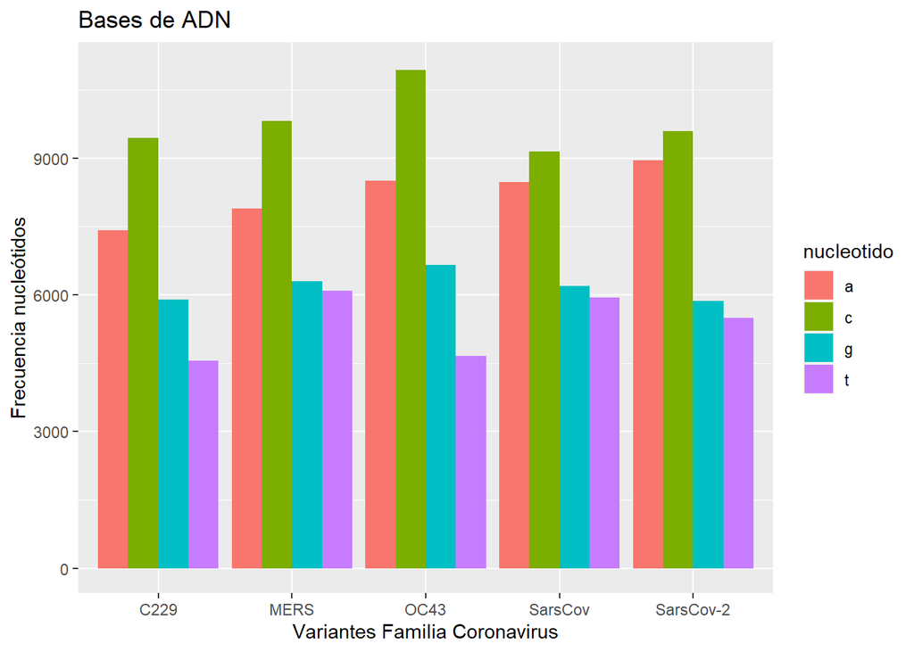

```r
#Crear Gráfica
plot <- ggplot(comparacion_bases, aes(x=variante, y=bases_virus, fill=nucleotido)) + geom_bar(stat='identity', position="dodge")

#Características de la Gáfica
graf <- plot + coord_cartesian(ylim = c(0, 11000)) + theme_gray() + labs(title="Bases de ADN", x="Variantes Familia Coronavirus", y="Frecuencia nucleótidos") + theme_gray()
graf
```

4. Análisis jerárquico global

```r
if (!requireNamespace("BiocManager", quietly = TRUE))
    install.packages("BiocManager")

BiocManager::install("ggtree")
if (!requireNamespace("BiocManager", quietly = TRUE))
    install.packages("BiocManager")

BiocManager::install("DECIPHER")
library(Biostrings)
library(seqinr)
library(adegenet)
library(ape)
library(ggtree)
library(DECIPHER)
library(viridis)
```

```r
library(ggplot2)
```

```r
#vector con viruses
virus <- c("NC_002645", "NC_006213", "NC_045512", "NC_019843", "NC_004718")
```

```r
secuencias <- read.GenBank(virus)
```

```r
write.dna(secuencias,  file ="coronaviruses.fasta", format = "fasta", append =
FALSE, nbcol = 6, colsep = " ", colw = 10)
```

```r
virus_sin_alinear <- readDNAStringSet("coronaviruses.fasta", format = "fasta")
virus_sin_alinear
```

```
## DNAStringSet object of length 5:
##     width seq                                               names
## [1] 27317 ACTTAAGTACCTTATCTATCTAC...AAAAAAAAAAAAAAAAAAAAAAA NC_002645
## [2] 30741 ATTGTGAGCGATTTGCGTGCGTG...AAAAAAAAAAAAAAAAAAAAAAA NC_006213
## [3] 29903 ATTAAAGGTTTATACCTTCCCAG...AAAAAAAAAAAAAAAAAAAAAAA NC_045512
## [4] 30119 GATTTAAGTGAATAGCTTGGCTA...AGATGATTTGCAAAAAAAAAAAA NC_019843
## [5] 29751 ATATTAGGTTTTTACCTACCCAG...AAAAAAAAAAAAAAAAAAAAAAA NC_004718
```

```r
virus_sin_alinear <- OrientNucleotides(virus_sin_alinear)
```

```
## ========================================================================================================================================================================================================
##
## Time difference of 0.16 secs
```

```r
virus_alineado <- AlignSeqs(virus_sin_alinear)
```

[output not shown]

```r
writeXStringSet(virus_alineado, file="virus_alineado.fasta")
```

```r
virus <- read.alignment("virus_alineado.fasta", format = "fasta")
```

```r
matriz_distancia <- dist.alignment(virus, matrix = "similarity")
```

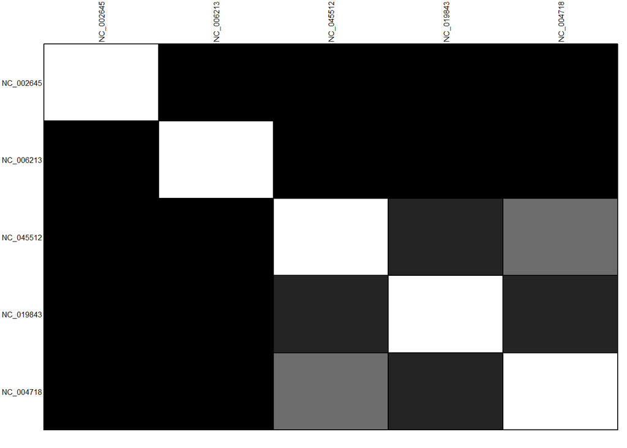

```r
df_distancia <- as.data.frame(as.matrix(matriz_distancia))
table.paint(df_distancia, cleg=0, clabel.row=.5, clabel.col=.5) + scale_color_viridis()
```

La matriz muestra el grado de similitud entre los distintos virus de la familia del coronavirus. Dependiendo del tono que se representa, la similitud. Es posible notar, que los virus más similares son SARS (NC_004718) y SARS-Cov-2 (NC_045512). Después, se observa que MERS (NC_019843) y SARS-Cov-2 (NC_045512) tienen un nivel de similitud un poco menor. Igualmente, SARS (NC_004718) y MERS (NC_019843) tienen un grado menor de aspectos comunes. Finalmente, se nota que las demás combinaciones de virus, cuentan con más diferencias entre ellas.

```r
arbol <- nj(matriz_distancia)
class(arbol)
```

```
## [1] "phylo"
```

```r
arbol <- ladderize(arbol)
```

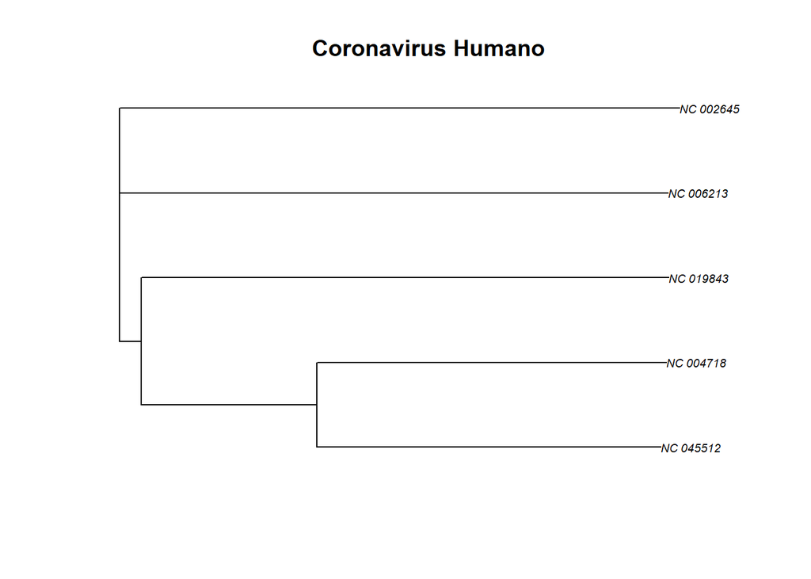

```r
plot(arbol, cex = 0.6)
title("Coronavirus Humano")
```

En el árbol filogenético hay 3 puntos de ramificación. El SARS-CoV y la variante de Wuhan comparten el ancestro común mas reciente, lo que los hace más similares entre sí que entre las otras variantes; asimismo, estas dos variantes comparten un ancestro común reciente con MERS-CoV. Las variantes 229E y OC43 no se relacionan con las otras variantes de las misma manera, es posible suponer que hay un ancestro común entre todas las variantes -el más lejano al SARS-CoV y a la variante de Wuhan-. Puesto a que no hay una raíz ni ramificación entre todas las variantes, es desconocido.

A partir de los análisis anteriores, es posible identificar que los virus de la familia coronavirus siguen una tendencia en cuanto a su número de nucleótidos. Además, se logró identificar que SARS, SARS-Cov-2 y MERS son los miembros de la familia con más similitudes

#### Referencias

F, W. (2020, January 17). Severe acute respiratory syndrome coronavirus 2 isolate Wuhan-Hu-1, complete genome. Retrieved from https://www.ncbi.nlm.nih.gov/nuccore/1798174254

Zaki, A. M., & van Boheemen, S. (2012). Middle East respiratory syndrome-related coronavirus isolate HCoV-EMC/ - Nucleotide - NCBI. National Center for Biotechnology Information. https://www.ncbi.nlm.nih.gov/nuccore/NC_019843

He, R. (2020, May 27) SARS coronavirus Tor2, complete genome. - Nucleotide - NCBI. National Center for Biotechnology Information. https://www.ncbi.nlm.nih.gov/nuccore/30271926

St-Jean, J. R. (2004). Human coronavirus OC43 strain ATCC VR-759, complete genome. https://www.ncbi.nlm.nih.gov/nuccore/NC_006213

Thiel,V., Herold,J., Schelle,B. and Siddell,S.G. (Agosto 2018). Infectious RNA transcribed in vitro from a cDNA copy of the human coronavirus genome cloned in vaccinia virus. -Nucleótido- NCBI. National Center for Biotechnology Information. Recuperado de https://www.ncbi.nlm.nih.gov/nuccore/12175745

Weiss, S., Navas-Martin, S. (Diciembre, 2005). Coronavirus Pathogenesis and the Emerging Pathogen Severe Acute Respiratory Syndrome Coronavirus. [Sitio Web]. Recuperado de https://www.ncbi.nlm.nih.gov/pmc/articles/PMC1306801/

```r
citation("dplyr")
```

```
##
##
##   Hadley Wickham, Romain François, Lionel Henry and Kirill Müller
##   (2021). dplyr: A Grammar of Data Manipulation. R package version
##   1.0.5. https://CRAN.R-project.org/package=dplyr
##
## A BibTeX entry for LaTeX users is
##
##   @Manual{,
##     title = {dplyr: A Grammar of Data Manipulation},
##     author = {Hadley Wickham and Romain François and Lionel Henry and Kirill Müller},
##     year = {2021},
##     note = {R package version 1.0.5},
##     url = {https://CRAN.R-project.org/package=dplyr},
##   }
```

```r
citation("tidyr")
```

```
##
##
##   Hadley Wickham (2021). tidyr: Tidy Messy Data. R package version
##   1.1.3. https://CRAN.R-project.org/package=tidyr
##
## A BibTeX entry for LaTeX users is
##
##   @Manual{,
##     title = {tidyr: Tidy Messy Data},
##     author = {Hadley Wickham},
##     year = {2021},
##     note = {R package version 1.1.3},
##     url = {https://CRAN.R-project.org/package=tidyr},
##   }
```

```r
citation("seqinr")
```

```
##
##
##   Charif, D. and Lobry, J.R. (2007)
##
## A BibTeX entry for LaTeX users is
##
##   @InCollection{,
##     author = {D. Charif and J.R. Lobry},
##     title = {Seqin{R} 1.0-2: a contributed package to the {R} project for statistical computing devoted to biological sequences retrieval and analysis.},
##     booktitle = {Structural approaches to sequence evolution: Molecules, networks, populations},
##     year = {2007},
##     editor = {U. Bastolla and M. Porto and H.E. Roman and M. Vendruscolo},
##     series = {Biological and Medical Physics, Biomedical Engineering},
##     pages = {207-232},
##     address = {New York},
##     publisher = {Springer Verlag},
##     note = {{ISBN :} 978-3-540-35305-8},
##   }
```

```r
citation("ggplot2")
```

```
##
##
##   H. Wickham. ggplot2: Elegant Graphics for Data Analysis.
##   Springer-Verlag New York, 2016.
##
## A BibTeX entry for LaTeX users is
##
##   @Book{,
##     author = {Hadley Wickham},
##     title = {ggplot2: Elegant Graphics for Data Analysis},
##     publisher = {Springer-Verlag New York},
##     year = {2016},
##     isbn = {978-3-319-24277-4},
##     url = {https://ggplot2.tidyverse.org},
##   }
```

```r
citation("Biostrings")
```

```
##
##
##   H. Pagès, P. Aboyoun, R. Gentleman and S. DebRoy (2020). Biostrings:
##   Efficient manipulation of biological strings. R package version
##   2.58.0. https://bioconductor.org/packages/Biostrings
##
## A BibTeX entry for LaTeX users is
##
##   @Manual{,
##     title = {Biostrings: Efficient manipulation of biological strings},
##     author = {H. Pagès and P. Aboyoun and R. Gentleman and S. DebRoy},
##     year = {2020},
##     note = {R package version 2.58.0},
##     url = {https://bioconductor.org/packages/Biostrings},
##   }
##
## ATTENTION: This citation information has been auto-generated from the
## package DESCRIPTION file and may need manual editing, see
## 'help("citation")'.
```

```r
citation("seqinr")
```

```
##
##
##   Charif, D. and Lobry, J.R. (2007)
##
## A BibTeX entry for LaTeX users is
##
##   @InCollection{,
##     author = {D. Charif and J.R. Lobry},
##     title = {Seqin{R} 1.0-2: a contributed package to the {R} project for statistical computing devoted to biological sequences retrieval and analysis.},
##     booktitle = {Structural approaches to sequence evolution: Molecules, networks, populations},
##     year = {2007},
##     editor = {U. Bastolla and M. Porto and H.E. Roman and M. Vendruscolo},
##     series = {Biological and Medical Physics, Biomedical Engineering},
##     pages = {207-232},
##     address = {New York},
##     publisher = {Springer Verlag},
##     note = {{ISBN :} 978-3-540-35305-8},
##   }
```

```r
citation("ape")
```

```
##
##
##   Paradis E. & Schliep K. 2019. ape 5.0: an environment for modern
##   phylogenetics and evolutionary analyses in R. Bioinformatics 35:
##   526-528.
##
## A BibTeX entry for LaTeX users is
##
##   @Article{,
##     title = {ape 5.0: an environment for modern phylogenetics and evolutionary analyses in {R}},
##     author = {E. Paradis and K. Schliep},
##     journal = {Bioinformatics},
##     year = {2019},
##     volume = {35},
##     pages = {526-528},
##   }
##
## As ape is evolving quickly, you may want to cite also its version
## number (found with 'library(help = ape)' or 'packageVersion("ape")').
```

```r
citation("ggtree")
```

```
##
##
##   Guangchuang Yu. Using ggtree to visualize data on tree-like
##   structures. Current Protocols in Bioinformatics, 2020, 69:e96. doi:
##   10.1002/cpbi.96
##
##   Guangchuang Yu, Tommy Tsan-Yuk Lam, Huachen Zhu, Yi Guan. Two methods
##   for mapping and visualizing associated data on phylogeny using
##   ggtree. Molecular Biology and Evolution 2018, 35(2):3041-3043. doi:
##   10.1093/molbev/msy194
##
##   Guangchuang Yu, David Smith, Huachen Zhu, Yi Guan, Tommy Tsan-Yuk
##   Lam. ggtree: an R package for visualization and annotation of
##   phylogenetic trees with their covariates and other associated data.
##   Methods in Ecology and Evolution 2017, 8(1):28-36.
##   doi:10.1111/2041-210X.12628
##
## To see these entries in BibTeX format, use 'print(<citation>,
## bibtex=TRUE)', 'toBibtex(.)', or set
## 'options(citation.bibtex.max=999)'.
```

```r
citation("DECIPHER")
```

```
##
## Wright ES (2016). "Using DECIPHER v2.0 to Analyze Big Biological
## Sequence Data in R." _The R Journal_, *8*(1), 352-359.
##
## A BibTeX entry for LaTeX users is
##
##   @Article{,
##     title = {Using DECIPHER v2.0 to Analyze Big Biological Sequence Data in R},
##     author = {Erik S. Wright},
##     journal = {The R Journal},
##     year = {2016},
##     volume = {8},
##     number = {1},
##     pages = {352-359},
##   }
```

```r
citation("viridis")
```

```
##
##
##   Simon Garnier, Noam Ross, Robert Rudis, Antônio P. Camargo, Marco
##   Sciaini, and Cédric Scherer (2021). Rvision - Colorblind-Friendly
##   Color Maps for R. R package version 0.6.0.
##
## A BibTeX entry for LaTeX users is
##
##   @Manual{,
##     title = {{viridis} - Colorblind-Friendly Color Maps for R},
##     author = {{Garnier} and {Simon} and {Ross} and {Noam} and {Rudis} and {Robert} and {Camargo} and Antônio Pedro and {Sciaini} and {Marco} and {Scherer} and {Cédric}},
##     year = {2021},
##     note = {R package version 0.6.0},
##     url = {https://sjmgarnier.github.io/viridis/},
##     doi = {10.5281/zenodo.4679424},
##     doi = {10.5281/zenodo.4679424},
##   }
```

```r
citation("ggmsa")
```

```
##
##
##   Guangchuang Yu and Lang Zhou (2021). ggmsa: Plot Multiple Sequence
##   Alignment using 'ggplot2'. R package version 0.0.6.
##   https://CRAN.R-project.org/package=ggmsa
##
## A BibTeX entry for LaTeX users is
##
##   @Manual{,
##     title = {ggmsa: Plot Multiple Sequence Alignment using 'ggplot2'},
##     author = {Guangchuang Yu and Lang Zhou},
##     year = {2021},
##     note = {R package version 0.0.6},
##     url = {https://CRAN.R-project.org/package=ggmsa},
##   }
```